# Prediction of readmissions with Anorexia Nervosa - rapport

[figure not shown]

[figure not shown]

[figure not shown]

[figure not shown]

# Introduktion og model

$$\begin{aligned}
&\text{Hans Christian Hansen}\;&(202005922)\\
&\text{Anne-Mette Hartved Dahl}\;&(201807410)\\
&\text{Morten Skovbjerg}\;&(202108037)\\
&\text{Carrie Susanne
Lovejoy}\;&(202106470)\end{aligned}$$

Projektet har haft til formål at modellere/forudsige risikoen for genindlæggelse i psykiatrien efter kontakt (stillet diagnose) for personer diagnosticeret med anorexia nervosa. Til det formål har vi lavet en overlevelsesanalyse over patienternes genindlæggelsesrate, baseret på antal dage siden kontakt, og grundet et højt antal potentielt irrelevante variable, brugt LASSO til modelselektion. Et andet formål har været at kunne visualisere og tyde, om og hvis i så fald hvor meget bestemte grupper af variable har større betydning end andre.

Til projektet har vi brugt data fra et studie over anoreksiske patienter vha. Statistikbanken fra Danmarks Statistik (DST). Det oprindelige datasæt indeholder information på 58076 personer, hvoraf 7774 er diagnosticeret med anoreksi, hvilket er dem af interesse i projektet. Af disse følger vi kun personer diagnosticeret efter 6-årsalderen, hvilket giver en casegruppe på 7759 personer. Endeligt var der ufuldstændig data på bl.a. PRS’er på 648 personer, hvilket giver et endeligt antal på 7111 personer. Til Cox-modellen er der registreret 1674 genindlæggelser som events, dvs. ca 23.54% blev genindlagt i løbet af perioden de blev fulgt.

Dertil indeholder vores datasæt ca. 440 variable baseret på register- og gendata tilgængelig gennem DST og NCRR på AU. En særlig begrænsning ved projektet er at, da vi har med personhenførbar data at gøre, er vores output begrænset til summary data (nærmere sagt har vi kun estimaterne fra regressionerne).

### Model og metode

Da vi i vores analyse har mange variable der kan have tvivlsom relevans for at forudsige anoreksi (og for genetiske variable er det endnu mere uklart, hvilke det skulle være), har vi anvendt LASSO-regularisering (ligning (4.20) i Reich, s. 128) på modellen til feature selection. LASSO ligner meget Ridge, som vi har set til forelæsningerne, dog udstyret med en anden norm til regulariseringsleddet. Dvs. koefficienterne estimeres ved

$$\hat{\beta}_{\text{LASSO}} =
\underset{\beta}{\arg\min} \sum_{i=1}^n (Y_i - \sum_{j=1}^p
X_{ij}\beta_j)^2 + \lambda \sum_{j=1}^p |\beta_j|$$

I modsætning til Ridge, tvinger LASSO de mindst betydende koefficienter mod 0, hvilket netop er hvad vi ønsker for vores datasæt.

På grund af begrænsninger med vores softwarepakker i R har vi ikke kunnet få estimater ud samtidigt med modelselektionen i LASSO, altså vi har været nødt til at køre to regressioner; den første til at udvælge variable fra LASSO og den sidste til at fitte de resulterende estimater.

#### Regressioner

Et af formålene med projektet har også været at se, om forskellige undermodeller prædikterer ens, og om dette kan visualiseres let. Til det formål har vi inddelt vores data (se siden “Data og variable”) i 11 input-grupper og lavet regressioner på hver kombination af disse, hvilket giver i alt $2^{11} = 2048$ forskellige regressioner.

### Det endelige produkt

Det endelige produkt (vises til eksamen) er en interaktiv Shiny-app der viser vores analyser hvori man frit og let kan se regressionsresultaterne på forskellige undermodeller af vores datasæt, inddelt i forskellige kategoriseringer af variable, ved hjælp af forest-plots med et visuelt intuitivt layout.

På grund af tekniske begrænsninger med måden, vi har udarbejdet det endelige produkt på, er siderne her primært en redegørelse for det overordnede arbejde. Til selve eksamen kan vi præsentere det interaktive led af selve produktet.

# Data og variable

Til projektet er der blevet brugt en række variable inddelt i forskellige grupper i tre overordnede kategorier, som vi hhv. har kaldt `baseline`, `somatic` og `PRS`.

### Baseline

Baseline-kategorien udgør de variable, som vi har vurderet som af særlig interesse eller meget sandsynlig til at påvirke risikoen for genindlæggelse og er derfor inkluderet i alle regressionerne.

Det inkluderer:

- De 5 største principal components for patienterne i studiet.
  - Dette kontrollerer for genetikken i forskellige befolkningsgrupper; dvs. genetiske forskelle for PRS’er indsamlet på danskere og ikke-danskere (f.eks. er engelske studier inkluderet) korrigeres for.
- Polygeniske scorer ved LDpred2.
  - Dvs. en fast PRS udregnet for seks forskellige diagnoser.
- Indikatorvariable for seks forskellige diagnoser.
- Om personen har været anbragt i en offentlig institution før 6-årsalderen.
- Personens køn.
- Om patienten har været indlagt for en ikke-psykisk sygdom før kontakt, dvs. potentielle traumatiske oplevelser.
- Patientens alder ved kontakt.

#### Oversigt over baseline-variable

| Variabel | Forklaring |
| --- | --- |
| PC1 | Principal Component |
| PC2 | Principal Component |
| PC3 | Principal Component |
| PC4 | Principal Component |
| PC5 | Principal Component |
| prs_ldpred2_ADHD | PRS udregnet via LDpred2 for ADHD-diagnoser |
| prs_ldpred2_Ano | PRS udregnet via LDpred2 for anoreksi-diagnoser |
| prs_ldpred2_ASD | PRS udregnet via LDpred2 for Asperger-diagnoser |
| prs_ldpred2_BP | PRS udregnet via LDpred2 for bipolær-diagnoser |
| prs_ldpred2_MDD | PRS udregnet via LDpred2 for depressive-diagnoser |

[output cut: 10 more lines]

### Somatic

Disse variable indeholder variable inddelt i følgende grupper:

- Diagnoser tilhørende patientens far (`Father`)
- Diagnoser tilhørende patientents mor (`Mother`)
- Kategoriske variable for forældrenes uddannelsesniveauer (`Educ`)
- Kategoriske variable for forældrenes indkomster (`Income`)
- Variable relaterende til fødslen (`Birth`), herunder fødselsvægt, gestationsalder og apgar-scorer (fødselstest for hvor godt en nyføst har klarert fødslen)
- Patientens civilstatus ved kontakt (`Civil Status`)

#### Somatiske variable

| Variabel | Kategori |
| --- | --- |
| F_ASD | Father |
| F_Anoreksi | Father |
| F_Skizofreni | Father |
| F_Bipolar | Father |
| F_MDD | Father |
| F_ADHD | Father |
| M_ASD | Mother |
| M_Anoreksi | Mother |
| M_Skizofreni | Mother |
| M_Bipolar | Mother |

[output cut: 11 more lines]

Af disse blev `M_ASD`, `F_Anoreksi` og `F_ASD` udelukket (alle indikatorvariable for deres respektive diagnoser), da de havde nul varians (skyldes evt. manglende data).

Der er relativt få variable (ca. 30) udarbejdet fra registerdata; det skyldes primært, at det meste data, vi havde adgang til, var ufuldstændigt, og derfor har vi kun inkluderet variable, som ikke gør vores case-gruppe endnu mindre.

### PRS

PRS’er (polygenic risk scores) er numeriske variable udregnet baseret på genetisk data på patienterne og befolkningsgrupper. Det er standardnormalfordelte variable som afspejler hvor stærkt patienten er associeret med forskellige personligheds- eller fysiske træk, risici for sygdomme eller andre idiomatiske træk. I analysen er de vigtige, idet de kan hjælpe med at forklare genetiske risikofaktorer for f.eks. anoreksi.

Til projektet har vi blandt andet fået adgang til følgende PRS-variable:

#### Oversigt over PRS-variable

| id | Reported_trait | Reported_trait_group |
| --- | --- | --- |
| GCST007710 | Anxiety/tension | Psychiatry |
| phen15 | Body mass index (Yengo 2018; phen15) | Anthropometric |
| GA3687 | Obesity | Anthropometric |
| GA165 | Hip circumference | Anthropometric |
| GCST006867 | Type 2 diabetes (Xue 2018) | Metabolic |
| phen16 | Waist-hip ratio (Yengo 2018) | Anthropometric |
| GA3682 | Abdominal and pelvic pain (main ICD10) | Gastrointestinal |
| GA3702 | Abdominal and pelvic pain (secondary ICD10) | Gastrointestinal |
| phen57 | AN | Psychiatry |
| GCST007322 | General risk tolerance | Risk-taking behaviour |

[output cut: 407 more lines]

Af disse er `phen57` blevet udelukket, da den er identisk med en af de øvrige PRS’er.

Til analysens formål har vi inddelt variablene i yderligere underkategorier (nogenlunde gjort ad-hoc):

- Personlighedsrelaterede adfærdsmønstre (`Behavior`)
- Livsstilsbaserede adfærdsmønstre (`Lifestyle`)
- Relateret til helbred (`Health`)
- Mentalt helbred (`Mental`)
- Diverse eller uden for kategori (`Miscellaneous`)

Det skal dog understreges, at variablenes inddeling er baseret på skøn og ikke nødvendigvis afspejler korrekte kategoriseringer.

### Resultater

For langt de fleste undermodeller, vi har inspiceret (se evt. siden “Plots og tabeller”), har tidligere somatiske sygdomme, skizofrenidiagnoser, PRS’er for anoreksi, alder ved stillet diagnose og om patienten har været anbragt vist sig at være de mest konsistent signifikante variable. Især skizofreni og at have været anbragt har prædikteret en meget høj risiko for genindlæggelse, hvilket evt. kan forklares ved at disse patienter har en evt. mere sårbar psyke end de øvrige patienter og udgør en lille sample size. Interessant ved alle disse variable er dog, at de alle er inkluderet i `baseline`, altså var vores formodning om, at disse variable kunne have betydning, formentligt korrekt.

Af genetisk data ses det generelt, at variable som relaterer til f.eks. kolesteroltal, spisevaner eller hals-/mundrelaterede er signifikante i de fleste modeller. Interessant nok er PRS-variable for mentalt helbred sjældent signifikante medmindre man *ikke* kontrollerer for fysisk helbred, hvilket strider imod vores intuition. Man ville forvente, at underliggende genetik skulle spille meget ind i en anoreksisk patients velvære.

Registerdata viser sig sjældent at være signifikant i nogen undermodeller, udover for de variable som vi har inkluderet i `baseline` (primært anbragt). Det vil tyde på at mange socioøkonomiske forhold, især fra forældrenes side, ikke spiller særligt meget ind i risikoen for genindlæggelse.

# Plots og tabeller

Vi har udvalgt nogle enkelte resultater som eksempel på projektet. Til hvert resultat, bestående af forskellige kombinationer af variable, er der et plot og en tilhørende tabel med resultaterne. I det endelige produkt kan man vælge mellem kun de signifikante eller alle estimater i regressionen, men til visualiseringerne her viser vi kun de signifikante variable.

### Resultater

Første eksempel er den mindste model som kun indeholder de variable vi har defineret som `baseline`, dvs. de variable som vi har vurderet mest interessant. Det viser sig, at mange af disse variable går igen i næsten alle regressioner.

### Plot

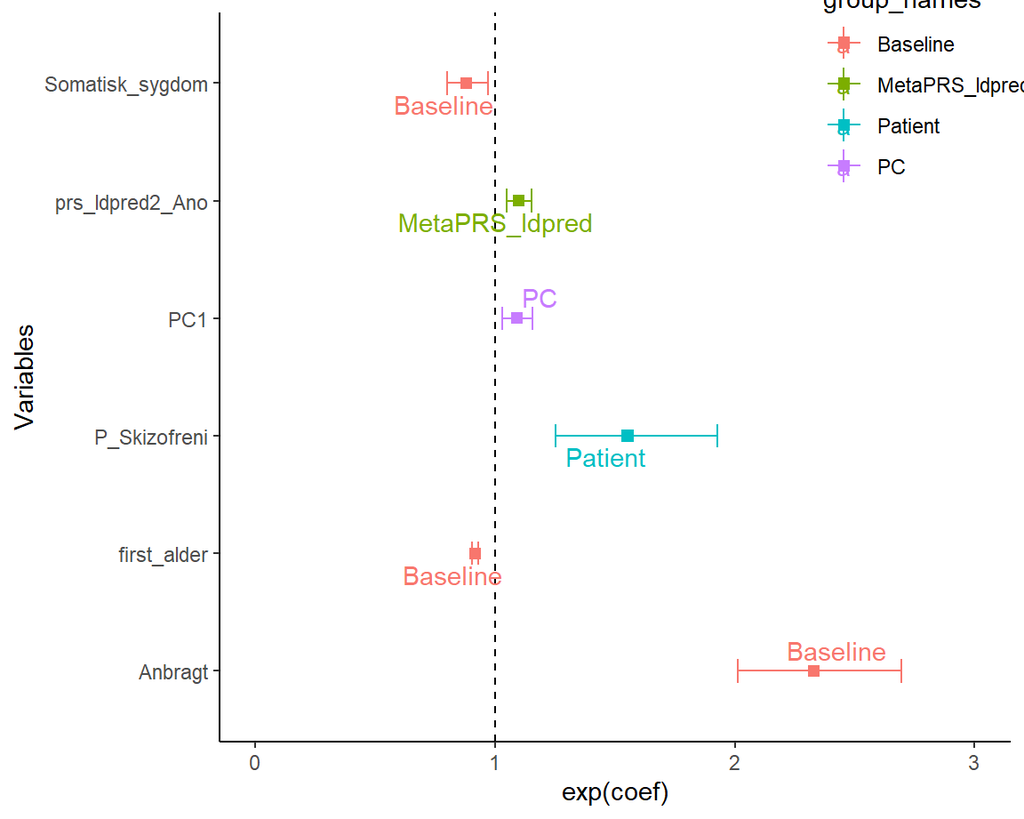

### Tabel

| variables | coef | exp(coef) | se(coef) | z | Pr(>\|z\|) | exp(-coef) | lower .95 | upper .95 |
| --- | --- | --- | --- | --- | --- | --- | --- | --- |
| PC1 | 0.09 | 1.09 | 0.03 | 2.87 | 0 | 0.92 | 1.03 | 1.16 |
| prs_ldpred2_Ano | 0.09 | 1.1 | 0.02 | 3.79 | 0 | 0.91 | 1.05 | 1.15 |
| P_Skizofreni | 0.44 | 1.55 | 0.11 | 4 | 0 | 0.64 | 1.25 | 1.92 |
| Anbragt | 0.85 | 2.33 | 0.07 | 11.33 | 0 | 0.43 | 2.01 | 2.7 |
| Somatisk_sygdom | -0.13 | 0.88 | 0.05 | -2.56 | 0.01 | 1.14 | 0.8 | 0.97 |
| first_alder | -0.09 | 0.92 | 0.01 | -12.75 | 0 | 1.09 | 0.9 | 0.93 |

Dette eksempel er den fulde model, dvs. alle 11 kategorier af variable er inkluderet i regressionen. Selv med næsten 400 genetiske variable ser vi igen mange af de variable, som indgår i den mindste model.

### Plot

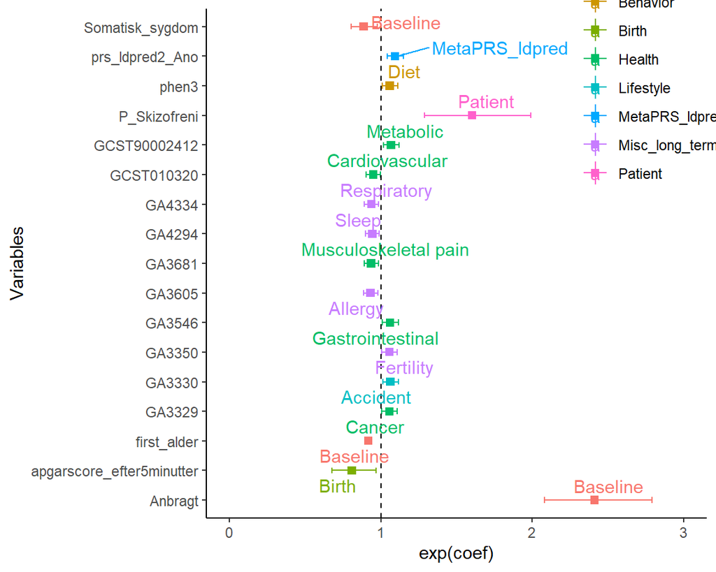

### Tabel

| variables | coef | exp(coef) | se(coef) | z | Pr(>\|z\|) | exp(-coef) | lower .95 | upper .95 |
| --- | --- | --- | --- | --- | --- | --- | --- | --- |
| prs_ldpred2_Ano | 0.09 | 1.1 | 0.02 | 3.68 | 0 | 0.91 | 1.04 | 1.15 |
| P_Skizofreni | 0.47 | 1.6 | 0.11 | 4.26 | 0 | 0.62 | 1.29 | 1.99 |
| Anbragt | 0.88 | 2.41 | 0.07 | 11.77 | 0 | 0.41 | 2.08 | 2.79 |
| Somatisk_sygdom | -0.12 | 0.89 | 0.05 | -2.4 | 0.02 | 1.13 | 0.8 | 0.98 |
| first_alder | -0.08 | 0.92 | 0.01 | -12.43 | 0 | 1.09 | 0.91 | 0.93 |
| phen3 | 0.06 | 1.06 | 0.02 | 2.33 | 0.02 | 0.94 | 1.01 | 1.11 |
| GA3330 | 0.06 | 1.06 | 0.02 | 2.5 | 0.01 | 0.94 | 1.01 | 1.12 |
| GA3329 | 0.05 | 1.06 | 0.02 | 2.19 | 0.03 | 0.95 | 1.01 | 1.11 |
| GCST010320 | -0.05 | 0.95 | 0.02 | -2.13 | 0.03 | 1.05 | 0.91 | 1 |
| GCST90002412 | 0.07 | 1.07 | 0.03 | 2.62 | 0.01 | 0.94 | 1.02 | 1.12 |

[output cut: 7 more lines]

Her har vi en regression med alle PRS’erne inkluderet. Bemærk her igen, hvor mange variable fra `baseline` er signifikante ligesom foroven.

### Plot

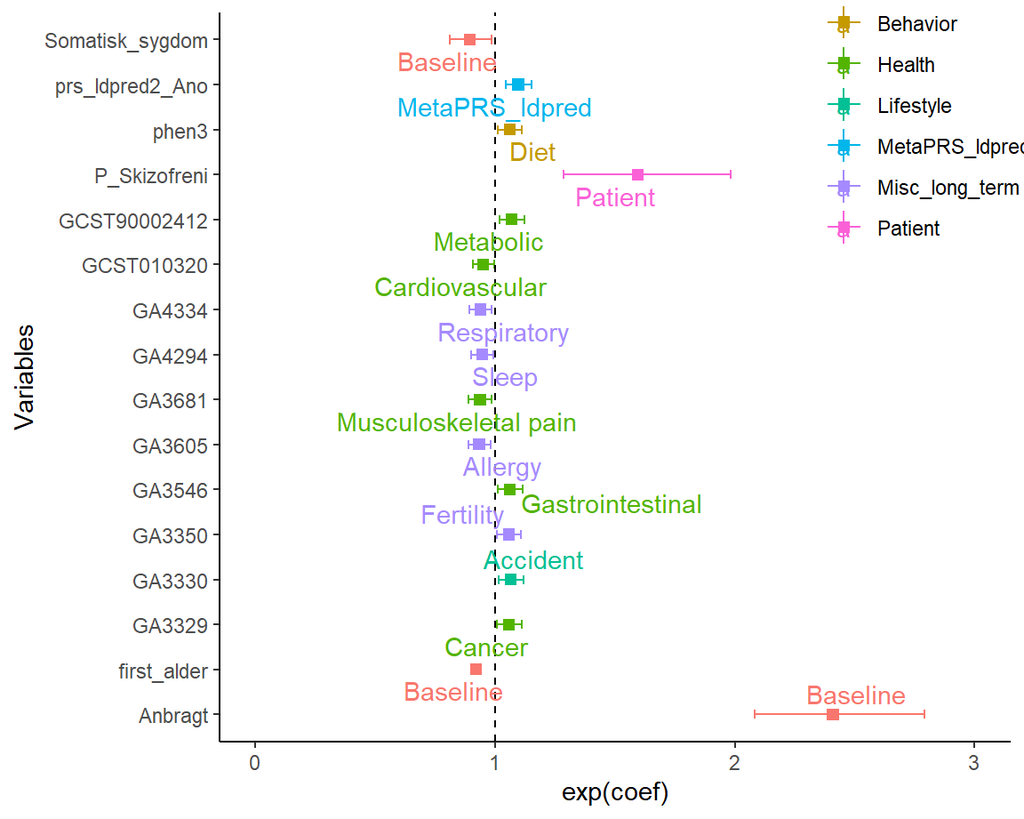

### Tabel

| variables | coef | exp(coef) | se(coef) | z | Pr(>\|z\|) | exp(-coef) | lower .95 | upper .95 |
| --- | --- | --- | --- | --- | --- | --- | --- | --- |
| prs_ldpred2_Ano | 0.09 | 1.1 | 0.02 | 3.68 | 0 | 0.91 | 1.04 | 1.15 |
| P_Skizofreni | 0.47 | 1.6 | 0.11 | 4.23 | 0 | 0.63 | 1.29 | 1.98 |
| Anbragt | 0.88 | 2.41 | 0.07 | 11.76 | 0 | 0.42 | 2.08 | 2.79 |
| Somatisk_sygdom | -0.11 | 0.89 | 0.05 | -2.27 | 0.02 | 1.12 | 0.81 | 0.98 |
| first_alder | -0.08 | 0.92 | 0.01 | -12.44 | 0 | 1.09 | 0.91 | 0.93 |
| phen3 | 0.06 | 1.06 | 0.02 | 2.34 | 0.02 | 0.94 | 1.01 | 1.11 |
| GA3330 | 0.06 | 1.06 | 0.02 | 2.5 | 0.01 | 0.94 | 1.01 | 1.12 |
| GA3329 | 0.05 | 1.06 | 0.02 | 2.21 | 0.03 | 0.95 | 1.01 | 1.11 |
| GCST010320 | -0.05 | 0.95 | 0.02 | -2.09 | 0.04 | 1.05 | 0.91 | 1 |
| GCST90002412 | 0.07 | 1.07 | 0.02 | 2.64 | 0.01 | 0.94 | 1.02 | 1.12 |

[output cut: 6 more lines]

Sidste eksempel inkluderer ingen ekstra genetiske variable, men kun dem vi har kaldt `somatic`, dvs. dem udarbejdet fra registerdata. Ved $\alpha = 0.05$ viser det sig, at ingen af disse er signifikante, og kun variable fra `baseline` er signifikante.

### Plot

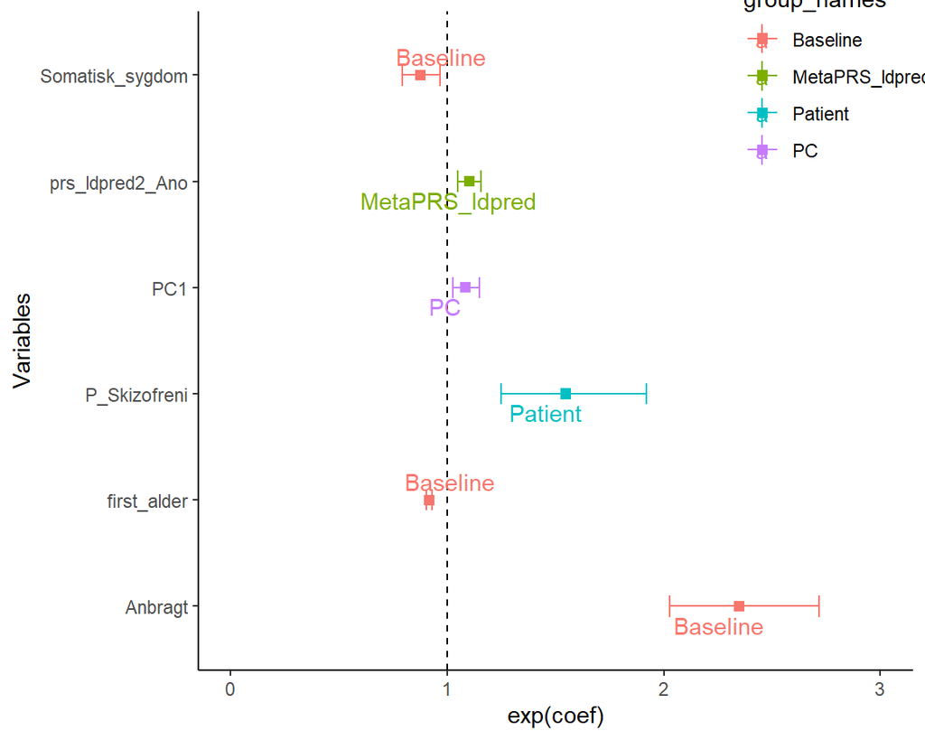

### Tabel

| variables | coef | exp(coef) | se(coef) | z | Pr(>\|z\|) | exp(-coef) | lower .95 | upper .95 |
| --- | --- | --- | --- | --- | --- | --- | --- | --- |
| PC1 | 0.08 | 1.08 | 0.03 | 2.78 | 0.01 | 0.92 | 1.02 | 1.15 |
| prs_ldpred2_Ano | 0.1 | 1.1 | 0.02 | 3.9 | 0 | 0.91 | 1.05 | 1.15 |
| P_Skizofreni | 0.44 | 1.55 | 0.11 | 3.96 | 0 | 0.65 | 1.25 | 1.92 |
| Anbragt | 0.85 | 2.35 | 0.07 | 11.39 | 0 | 0.43 | 2.03 | 2.72 |
| Somatisk_sygdom | -0.13 | 0.88 | 0.05 | -2.65 | 0.01 | 1.14 | 0.79 | 0.97 |
| first_alder | -0.09 | 0.92 | 0.01 | -12.8 | 0 | 1.09 | 0.9 | 0.93 |